# semantically meaningful notebooks

[@tonyfast](https://github.com/tonyfast) s notebooks

**site navigation**

**notebook summary**

**title**

semantically meaningful notebooks

**description**

this is the first presentation of the nbconvert-a11y template for assistive reading experiences in notebooks. these templates look beyond web content accessibility guidelines to construct idealized experiences for assistive technology.

**cells**

16 total

2 code

**state**

executed out of order

**language**

python

**lines of code**

**outputs**

2

execution_count

cell_type

toolbar

started_at

completed_at

source

loc

metadata

outputs

In [ ]

markdown

actions

```
# semantically meaningful notebooks

this is the first presentation of the `nbconvert-a11y` template for assistive reading experiences in notebooks. these templates look beyond web content accessibility guidelines to construct idealized experiences for assistive technology.

1. perceivable notebooks
2. operable notebooks
3. notebook demo
4. robust notebooks
```

8

# semantically meaningful notebooks

this is the first presentation of the `nbconvert-a11y` template for assistive reading experiences in notebooks. these templates look beyond web content accessibility guidelines to construct idealized experiences for assistive technology.

1. perceivable notebooks
2. operable notebooks
3. notebook demo
4. robust notebooks

In [ ]

markdown

actions

```
## TLDR

* EVERYONE, including assistive technology users, should have accessible developer experiences
* <q>HTML is our matter</q> for accessible experiences
* WCAG is anachronistic for interactive computing education
* reference implementations (eg [ARIA practice guides](https://www.w3.org/WAI/ARIA/apg/patterns/)) provide valuable calibrations for more complex applications
```

6

## TLDR

- EVERYONE, including assistive technology users, should have accessible developer experiences
- HTML is our matter for accessible experiences
- WCAG is anachronistic for interactive computing education
- reference implementations (eg [ARIA practice guides](https://www.w3.org/WAI/ARIA/apg/patterns/) ) provide valuable calibrations for more complex applications

In [ ]

markdown

actions

```
## beyond wcag

* [section 508 amendent of the rehabiliation act of 1973](https://en.wikipedia.org/wiki/Section_508_Amendment_to_the_Rehabilitation_Act_of_1973) is drastically insufficient for the needs of interactive computing technology.
* [WCAG 2.0](https://www.w3.org/TR/WCAG20/) was published in Dec 2008 long before the demanding needs of modern javascript (eg [Modern Health, frameworks, performance, and harm ](https://ericwbailey.website/published/modern-health-frameworks-performance-and-harm/))
* [WCAG 2.2](https://www.w3.org/TR/WCAG22/), adopted in October 2023, is a more equitable goal with clearer specifications for implementers and testers than the prior versions. satisfy AAA and allow the ability to downgrade when access needs are less important.
* federal compliance goals actively neglect the needs of assistive technology users in modern learning environments and creates a two-tier system.

* the principles of [WCAG](https://www.w3.org/TR/WCAG/) are limited for computational literacies

    <ul class=barb aria-label="accessibility principles for web content accessibility guidelines">
    <li><a href="https://github.com/Chartability/POUR-CAF#perceivable">perceivable</a></li>
    <li><a href="https://github.com/Chartability/POUR-CAF#operable">operable</a></li>
    <li><a href="https://github.com/Chartability/POUR-CAF#understandable">understandable</a>
    </li>
    <li><a href="https://github.com/Chartability/POUR-CAF#robust">robust</a>
    </li>
    </ul>
```

17

## beyond wcag

- [section 508 amendent of the rehabiliation act of 1973](https://en.wikipedia.org/wiki/Section_508_Amendment_to_the_Rehabilitation_Act_of_1973) is drastically insufficient for the needs of interactive computing technology.
- [WCAG 2.0](https://www.w3.org/TR/WCAG20/) was published in Dec 2008 long before the demanding needs of modern javascript (eg [Modern Health, frameworks, performance, and harm](https://ericwbailey.website/published/modern-health-frameworks-performance-and-harm/) )
- [WCAG 2.2](https://www.w3.org/TR/WCAG22/) , adopted in October 2023, is a more equitable goal with clearer specifications for implementers and testers than the prior versions. satisfy AAA and allow the ability to downgrade when access needs are less important.
- federal compliance goals actively neglect the needs of assistive technology users in modern learning environments and creates a two-tier system.
- the principles of [WCAG](https://www.w3.org/TR/WCAG/) are limited for computational literacies
  - perceivable
  - operable
  - understandable
  - robust

In [ ]

markdown

actions

```
## what if web content accessibility guidelines cared about visualization and data?

<figure>
<figcaption>
<q cite="https://github.com/Chartability/POUR-CAF"><a href="https://chartability.fizz.studio/">Chartability</a> is a set of heuristics for ensuring that data visualizations, systems, and interfaces are accessible.</q>
<br/>
the first four principles extend from web content accessibility guidelines. the last three principles are the additional principles for accessibile data experiences.
</figcaption>
<ul class=barb aria-label="accessibility principles for accessibile data experiences.">
<li><a href="https://github.com/Chartability/POUR-CAF#perceivable">perceivable</a>
<q>User must be able to easily identify content using their senses: sight, sound, and touch.</q></li>
<li><a href="https://github.com/Chartability/POUR-CAF#operable">operable</a>
<q>All controls must be error-tolerant, discoverable, and multi-modal (not just mouse operable, but using keyboard, etc).</q></li>
<li><a href="https://github.com/Chartability/POUR-CAF#understandable">understandable</a>
<q>Any information or data are presented without ambiguity, with clarity, and in a way that minimizes cognitive load.
</q></li>
<li><a href="https://github.com/Chartability/POUR-CAF#robust">robust</a>
<q>The design is compliant with existing standards and works with the user’s compliant, assistive technologies of choice.
</q></li>
<li><a href="https://github.com/Chartability/POUR-CAF#compromising">compromising</a>
<q>(Understandable, yet Robust): Information flows must provide transparency, tolerance, and consideration for different ways that users with assistive technologies and disabilities will prefer to consume different information.</q></li>
<li><a href="https://github.com/Chartability/POUR-CAF#assistive">assistive</a>
<q>(Understandable and Perceivable but labor-reducing): Interface must be intelligent and multi-sensory in a way that reduces the cognitive and functional labor required for use.
</q></li>
<li><a href="https://github.com/Chartability/POUR-CAF#flexible">flexible</a>
<q>(Perceivable and Operable, yet Robust): Design must respect user settings from user agents (browsers, operating systems, applications) and provide presentation and operation control.
</q></li>
</ul>

</figure>

read more about the relationship between <a href="https://github.com/deathbeds/nbconvert-a11y/wiki/accessible-computational-notebooks">accessible computational notebooks</a> and other <a href="https://www.w3.org/WAI/about/">web accessibility initiatives</a> on the <code>nbconvert-a11y</code> <a href="https://github.com/deathbeds/nbconvert-a11y/wiki">work in progress wiki</a>.
```

32

## what if web content accessibility guidelines cared about visualization and data?

[Chartability](https://chartability.fizz.studio/) is a set of heuristics for ensuring that data visualizations, systems, and interfaces are accessible.  
the first four principles extend from web content accessibility guidelines. the last three principles are the additional principles for accessibile data experiences.

- perceivable User must be able to easily identify content using their senses: sight, sound, and touch.
- operable All controls must be error-tolerant, discoverable, and multi-modal (not just mouse operable, but using keyboard, etc).
- understandable Any information or data are presented without ambiguity, with clarity, and in a way that minimizes cognitive load.
- robust The design is compliant with existing standards and works with the user’s compliant, assistive technologies of choice.
- compromising (Understandable, yet Robust): Information flows must provide transparency, tolerance, and consideration for different ways that users with assistive technologies and disabilities will prefer to consume different information.
- assistive (Understandable and Perceivable but labor-reducing): Interface must be intelligent and multi-sensory in a way that reduces the cognitive and functional labor required for use.
- flexible (Perceivable and Operable, yet Robust): Design must respect user settings from user agents (browsers, operating systems, applications) and provide presentation and operation control.

read more about the relationship between accessible computational notebooks and other web accessibility initiatives on the nbconvert-a11y work in progress wiki.

In [ 4 ]

code

actions

```
%%html
<!-- styling for the presentation-->
<style>
.barb li {
    list-style: none;
    a {font-size: 400%;}
    q {display: block; font-size: 150%; text-transform: lowercase;}
    background-color: var(--bg-color, var(--jp-layout-color0
                                          , white));
    font-weight: 1000;
    &:nth-child(2n+1) {filter: invert(100%);}
    &:nth-child(4) ~ li {text-transform: uppercase;}
    a:visited, a:link {color: unset; }
}
</style>
```

15

In [ ]

markdown

actions

```
## designing assistive interfaces for POUR-CAF outcomes

accessibility is the floor.
our perceivable designs consider all the sensory modalities that are possible with hypermedia.
we'll find that correctly choosing semantics from the html standard has superior accessibility outcomes.

* how is the story percievable?
    * what does the story feel like?
    * what does the story sound like?
    * what does the story look like?
* how operable and understandable is your opinion?
    * who are you including?
    * who are you excluding?
    * is it configurable?
    * what would [game accessibility guidelines say](https://gameaccessibilityguidelines.com/full-list/)?
* how robust is your approach?
    * automated testing
        * did you validate the html data structure?
        * did you check the accessibility tree?
    * user testing
        * did you test with at least one screen reader?
        * how you consulted affected communities?
```

22

## designing assistive interfaces for POUR-CAF outcomes

accessibility is the floor. our perceivable designs consider all the sensory modalities that are possible with hypermedia. we'll find that correctly choosing semantics from the html standard has superior accessibility outcomes.

- how is the story percievable?
  - what does the story feel like?
  - what does the story sound like?
  - what does the story look like?
- how operable and understandable is your opinion?
  - who are you including?
  - who are you excluding?
  - is it configurable?
  - what would [game accessibility guidelines say](https://gameaccessibilityguidelines.com/full-list/) ?
- how robust is your approach?
  - automated testing
    - did you validate the html data structure?
    - did you check the accessibility tree?
  - user testing
    - did you test with at least one screen reader?
    - how you consulted affected communities?

In [ ]

markdown

actions

```
## demo: what does the story feel like?

a demonstration of standard, low vision, and screen navigation of the `nbconvert-a11y` template.

* tab stops

 ![a snapshot of the tab stops in a template starting from the url](attachment:515bb263-f39f-44ac-9bc6-c689e9a6b3b6.png)

  > non-standard tabbing events are plaguing jupyter keyboard accessibility. see [tab traps pr](https://github.com/jupyterlab/jupyterlab/pull/14115)

* screen reader navigation - screen readers have more tactile dimensions than otherwise


    * cell list navigation

        ![a snapshot of the list item navigation illustrating how cells can be navigated.](attachment:5bfbc41e-3aee-442e-9ca4-4308933cc661.png)

    * cell landmark navigation

        ![a snapshot of an alternative cell navigation mode using landmarks.](attachment:503f2b37-9845-43ed-9488-1fceb51da309.png)

    * > [standard jupyter keyboard shortcuts conflict standard screen reader shortcuts.](https://github.com/jupyterlab/jupyterlab/issues/15303)
* currently, we use the suspect [`accesskey`](https://developer.mozilla.org/en-US/docs/Web/HTML/Global_attributes/accesskey) attribute for cell navigation and settings.
* conditionally operable [`dialog`](https://www.scottohara.me/blog/2023/01/26/use-the-dialog-element.html) and [`details`](https://adrianroselli.com/2019/04/details-summary-are-not-insert-control-here.html) options
    * [include a visual table of contents](https://github.com/Iota-School/notebooks-for-all/issues/9)
    * ![image.png](attachment:0ee2a3c2-8bdc-4c72-9992-9ab81b93476c.png)
    * ![image.png](attachment:e61258ba-68ae-41fa-b92a-5f7bdd8596ce.png)
    * explore more advanced `role=widget` `grid` or `tree` that require javascript interventions.
```

30

## demo: what does the story feel like?

a demonstration of standard, low vision, and screen navigation of the `nbconvert-a11y` template.

- tab stops

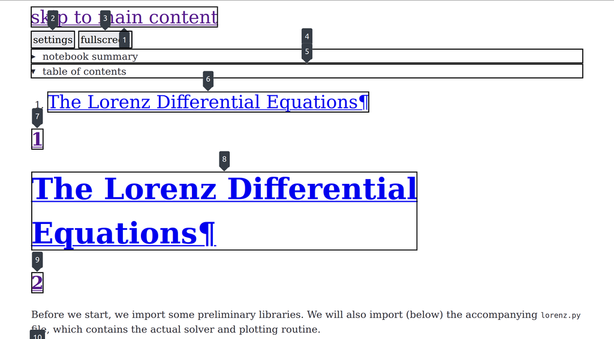

> non-standard tabbing events are plaguing jupyter keyboard accessibility. see [tab traps pr](https://github.com/jupyterlab/jupyterlab/pull/14115)
- screen reader navigation - screen readers have more tactile dimensions than otherwise
  - cell list navigation

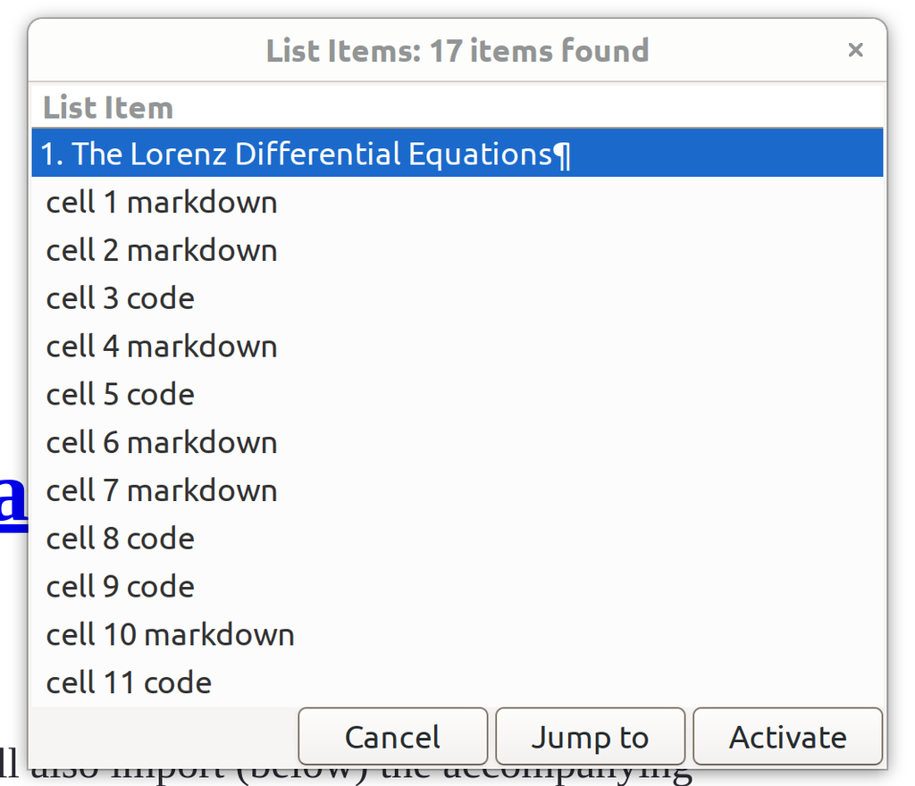

  - cell landmark navigation

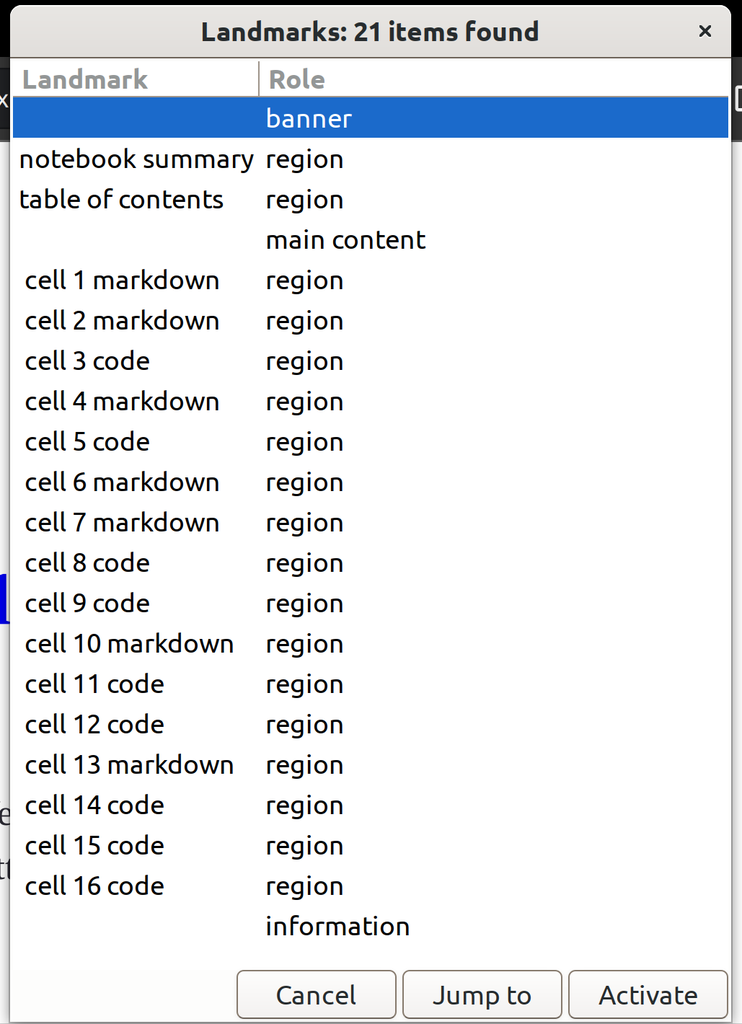

  - > [standard jupyter keyboard shortcuts conflict standard screen reader shortcuts.](https://github.com/jupyterlab/jupyterlab/issues/15303)
- currently, we use the suspect [`accesskey`](https://developer.mozilla.org/en-US/docs/Web/HTML/Global_attributes/accesskey) attribute for cell navigation and settings.
- conditionally operable [`dialog`](https://www.scottohara.me/blog/2023/01/26/use-the-dialog-element.html) and [`details`](https://adrianroselli.com/2019/04/details-summary-are-not-insert-control-here.html) options
  - [include a visual table of contents](https://github.com/Iota-School/notebooks-for-all/issues/9)

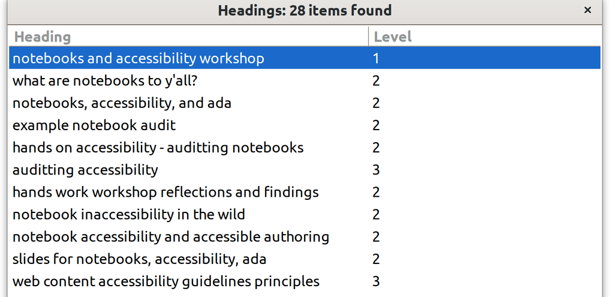

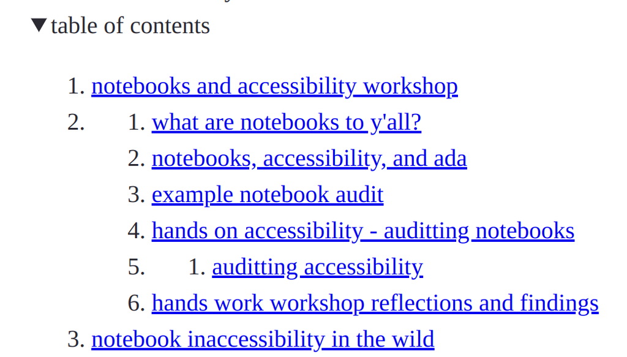

  - explore more advanced `role=widget` `grid` or `tree` that require javascript interventions.

In [ ]

markdown

actions

```
in real interactive applications, technincal debt makes it hard to determine the accessible notebook experience in modern applications. they are not designed to be accessible so they are bad references for our goal. reference templates give us the ability to test expectations and implement our applications accordingly.
```

1

in real interactive applications, technincal debt makes it hard to determine the accessible notebook experience in modern applications. they are not designed to be accessible so they are bad references for our goal. reference templates give us the ability to test expectations and implement our applications accordingly.

In [ ]

markdown

actions

```
## what does the story sound like?

we'll listen different aspects of screen reader navigation.

* the gestalt of a notebook
    * at a glance, sighted visitors can assess overall qualities of notebooks. what are some?
* cell navigation, we can't know what is best for generic content
* aria live to indicate changes
  * the reference template provided a valuable test bed for aria live best practices to influence [jupyterlab](https://github.com/jupyterlab/jupyterlab/pull/15048)
```

11

## what does the story sound like?

we'll listen different aspects of screen reader navigation.

- the gestalt of a notebook
  - at a glance, sighted visitors can assess overall qualities of notebooks. what are some?
- cell navigation, we can't know what is best for generic content
- aria live to indicate changes
  - the reference template provided a valuable test bed for aria live best practices to influence [jupyterlab](https://github.com/jupyterlab/jupyterlab/pull/15048)

In [ ]

markdown

actions

```
## what does the story look like?

* color and text settings
* activity log

do we try to cram too much information into our narrow visual channels? what happens if we express more of the electromagnetic spectrum?

http://www.eklhad.net/philosophy.html
```

8

## what does the story look like?

- color and text settings
- activity log

do we try to cram too much information into our narrow visual channels? what happens if we express more of the electromagnetic spectrum?

http://www.eklhad.net/philosophy.html

In [ ]

markdown

actions

```
## did you test?

https://github.com/Iota-School/notebooks-for-all/pull/73

10/18/2023 - https://www.youtube.com/watch?v=GkINFX3aJw0
10/25/2023 - https://www.youtube.com/watch?v=Ku-leCdn6hk

automated and manual testing

* is the html validated?
https://validator.w3.org/
https://github.com/deathbeds/nbconvert-a11y/blob/main/nbconvert_a11y/pytest_w3c.py

* axe



* what does the accessibility tree look like?

No Table (Critical)

https://github.com/Chartability/POUR-CAF?tab=readme-ov-file#no-table-critical

* automated screen reader testing is still a working in progress
```

24

## did you test?

https://github.com/Iota-School/notebooks-for-all/pull/73

10/18/2023 - https://www.youtube.com/watch?v=GkINFX3aJw0 10/25/2023 - https://www.youtube.com/watch?v=Ku-leCdn6hk

automated and manual testing

- is the html validated? https://validator.w3.org/ https://github.com/deathbeds/nbconvert-a11y/blob/main/nbconvert_a11y/pytest_w3c.py
- axe
- what does the accessibility tree look like?

No Table (Critical)

https://github.com/Chartability/POUR-CAF?tab=readme-ov-file#no-table-critical

- automated screen reader testing is still a working in progress

In [ ]

markdown

actions

```
## tables and forms


html is our matter.
it provides the accessible substrate for reading notebooks.
through progressive enhancement

we acheive superior assistive technology experiences for computational works
by expressing more of the html5 vocabulary to capture notebooks semantics.

we still strongly to the first principle of aria, and strongly bend the second rule.

* table of contents
* activity log
* notebook book summary
    * how do we make the gestalt of a computational work audible and tactile?

https://alistapart.com/article/web-typography-tables/
```

18

## tables and forms

html is our matter. it provides the accessible substrate for reading notebooks. through progressive enhancement

we acheive superior assistive technology experiences for computational works by expressing more of the html5 vocabulary to capture notebooks semantics.

we still strongly to the first principle of aria, and strongly bend the second rule.

- table of contents
- activity log
- notebook book summary
  - how do we make the gestalt of a computational work audible and tactile?

https://alistapart.com/article/web-typography-tables/

In [ ]

markdown

actions

```
reducing the distance between source and html.
accessibility can only be evaluated in html!
```

2

reducing the distance between source and html. accessibility can only be evaluated in html!

In [ ]

markdown

actions

```
## open questions

- [x] accessible application
- [x] accessible input group forms
- [ ] accessible output groups
- [ ] accessible interactive computing
- [ ] accessible debugging
- [ ] accessible collaboration

* more people try to use this
* user testing

* outputs! outputs!
    * nonvisual representation of empty outputs https://github.com/deathbeds/nbconvert-a11y/issues/33
    * [structured tracebacks](2024-03-05-traceback-figure-tables.ipynb.html)
    * [accessible pandas dataframes](2024-02-26-multiindex-aria.html)
    * [better semantics for python reprs](2024-03-04-semantic-outputs.html)
* automated tests
* executing notebooks
```

19

## open questions

- accessible application
- accessible input group forms
- accessible output groups
- accessible interactive computing
- accessible debugging
- accessible collaboration
- more people try to use this
- user testing
- outputs! outputs!
  - nonvisual representation of empty outputs https://github.com/deathbeds/nbconvert-a11y/issues/33
  - structured tracebacks
  - accessible pandas dataframes
  - better semantics for python reprs
- automated tests
- executing notebooks

In [ ]

markdown

actions

```
https://github.com/deathbeds/nbconvert-a11y/wiki/accessible-computational-notebooks#accessibility-standards-and-recommendations
```

1

https://github.com/deathbeds/nbconvert-a11y/wiki/accessible-computational-notebooks#accessibility-standards-and-recommendations

In [ 2 ]

code

actions

```
%%html
<h3><a href="https://science.nasa.gov/mission/hubble/multimedia/sonifications/">data sonification - westerlund 2</a></h3>

<blockquote>
This is a cluster of young stars – about one to two million years old – located about 20,000 light-years from Earth. In its visual image form, data from Hubble (green and blue) reveals thick clouds where stars are forming, while X-rays seen by Chandra (purple) penetrate through that haze. In the sonified version of this data, sounds sweep from left to right across the field of view with brighter light producing louder sound. The pitch of the notes indicates the vertical position of the sources in the image with the higher pitches towards the top of the image. The Hubble data is played by strings, either plucked for individual stars or bowed for diffuse clouds. Chandra’s X-ray data is represented by bells, and the more diffuse X-ray light is played by more sustained tones.
</blockquote>

<iframe width="840" height="473" src="https://www.youtube.com/embed/ESz8Cvirh00" title="Data Sonification: Westerlund 2 (Multiwavelength)" frameborder="0" allow="accelerometer; autoplay; clipboard-write; encrypted-media; gyroscope; picture-in-picture; web-share" allowfullscreen></iframe>
```

8

### data sonification - westerlund 2

> This is a cluster of young stars – about one to two million years old – located about 20,000 light-years from Earth. In its visual image form, data from Hubble (green and blue) reveals thick clouds where stars are forming, while X-rays seen by Chandra (purple) penetrate through that haze. In the sonified version of this data, sounds sweep from left to right across the field of view with brighter light producing louder sound. The pitch of the notes indicates the vertical position of the sources in the image with the higher pitches towards the top of the image. The Hubble data is played by strings, either plucked for individual stars or bowed for diffuse clouds. Chandra’s X-ray data is represented by bells, and the more diffuse X-ray light is played by more sustained tones.

[video not shown]